# Статическая маршрутизация в Интернете

Лабораторная работа №14

Гафоров Нурмухаммад

Российский университет дружбы народов, Москва, Россия

11.05.2026

# Цель работы

## Цель

Настроить взаимодействие локальных сетей организации  
через сеть провайдера с использованием статической маршрутизации.

# Ход выполнения

## Общая топология

- Создана распределённая сеть организации
- Подключены площадки:
  - основное здание
  - 42-й квартал
  - общежитие
  - филиал в Сочи
- Использованы маршрутизаторы, коммутаторы и сеть провайдера

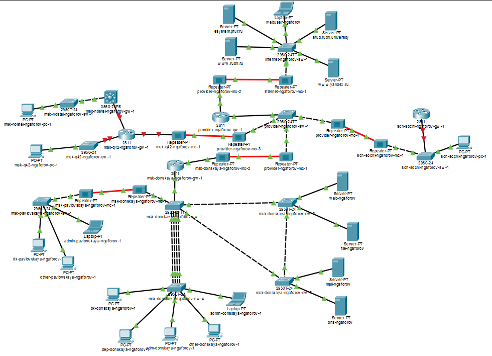

Общая топология сети

## Настройка сети провайдера

- На коммутаторе провайдера настроены trunk-порты
- Созданы VLAN для удалённых площадок:
  - VLAN 5 — 42-й квартал
  - VLAN 6 — филиал в Сочи
- VLAN-интерфейсы активированы

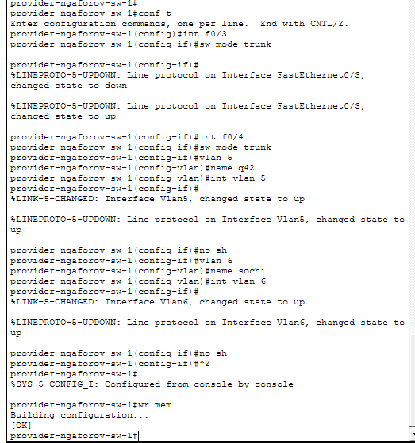

Настройка VLAN на коммутаторе провайдера

## Подключение основного здания

- На маршрутизаторе основного здания созданы подинтерфейсы
- Использована инкапсуляция IEEE 802.1Q
- Настроены каналы:
  - к сети 42-го квартала
  - к филиалу в Сочи

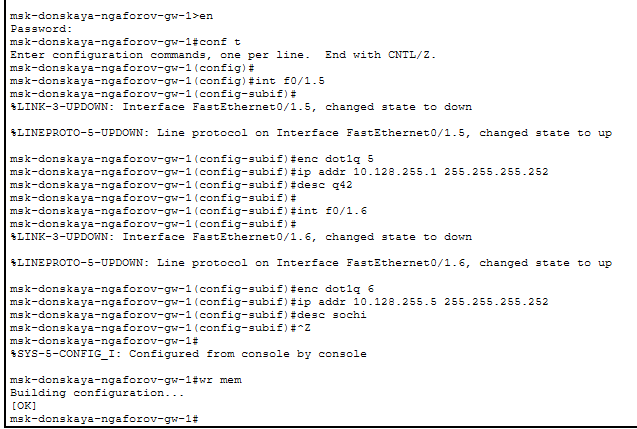

Подинтерфейсы основного маршрутизатора

## Подключение 42-го квартала

- Активирован интерфейс маршрутизатора
- Создан подинтерфейс для VLAN 5
- Назначен адрес из сети соединения с провайдером

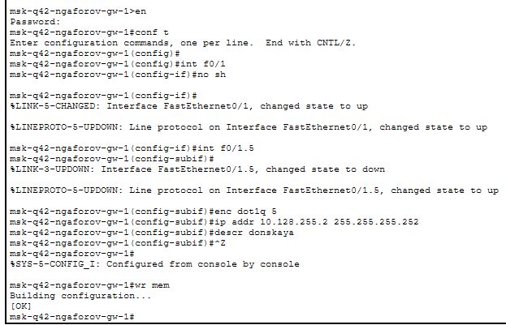

Подключение 42-го квартала

## Подключение филиала в Сочи

- На коммутаторе филиала настроены trunk-порты
- Создан VLAN 6
- На маршрутизаторе создан подинтерфейс для связи через провайдера

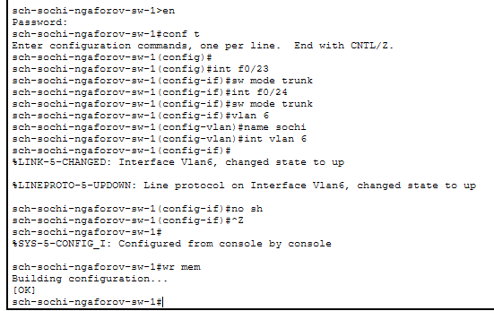

Настройка коммутатора Сочи

## Маршрутизатор филиала

- Активирован физический интерфейс
- Создан подинтерфейс VLAN 6
- Назначен адрес для соединения с основным зданием

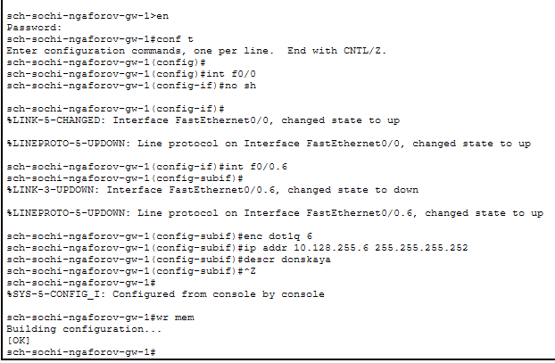

Настройка маршрутизатора Сочи

## VLAN в сети 42-го квартала

- Настроены VLAN:
  - VLAN 201 — основная сеть
  - VLAN 202 — сеть управления
- Для VLAN созданы подинтерфейсы маршрутизатора
- Назначены адреса шлюзов

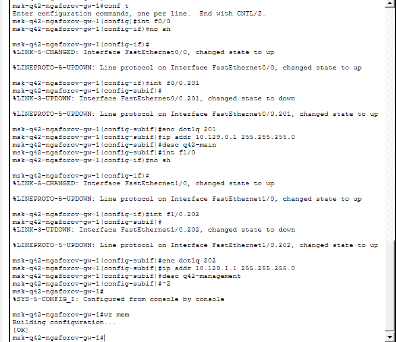

VLAN 201 и VLAN 202

## Коммутатор 42-го квартала

- Порт к маршрутизатору переведён в trunk
- Порт к ПК настроен как access
- Access-порт привязан к VLAN 201

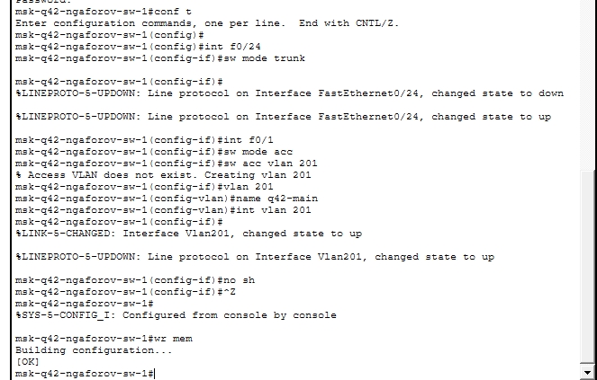

Настройка коммутатора 42-го квартала

## Сеть общежития

- Настроены VLAN:
  - VLAN 202 — управление
  - VLAN 301 — основная сеть общежития
- Настроены trunk-соединения
- Назначены адреса шлюзов VLAN

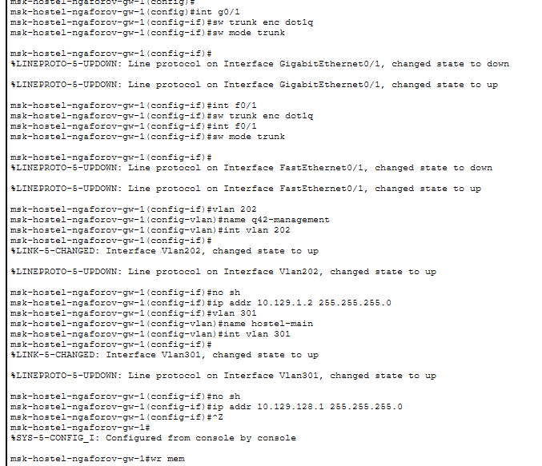

Настройка сети общежития

## Коммутатор общежития

- Интерфейс к маршрутизатору переведён в trunk
- Интерфейс к ПК настроен как access
- Access-порт привязан к VLAN 301

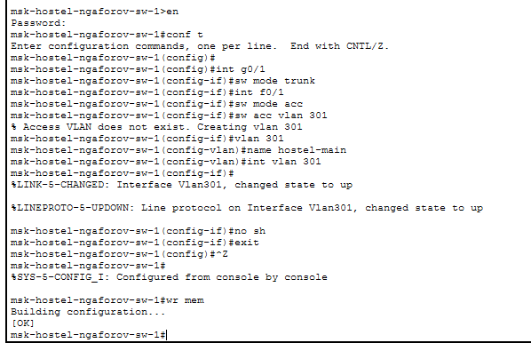

Настройка коммутатора общежития

## Локальная сеть филиала

- Созданы VLAN:
  - VLAN 401 — основная сеть филиала
  - VLAN 402 — сеть управления
- Настроены подинтерфейсы маршрутизатора
- Назначены адреса шлюзов

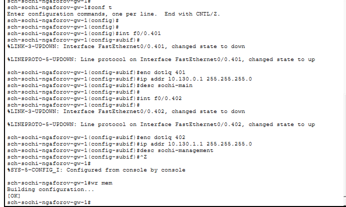

VLAN филиала в Сочи

## Коммутатор филиала

- Порт к ПК переведён в access-режим
- Порт привязан к VLAN 401
- VLAN получил имя sochi-main

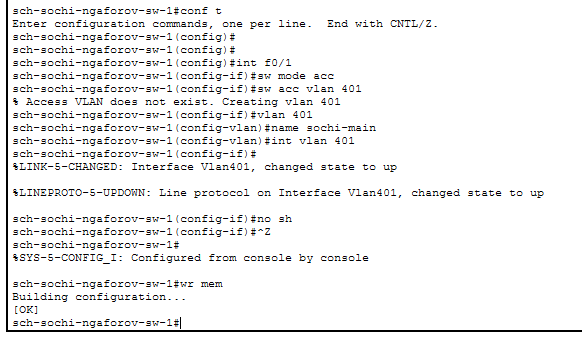

Access-порт VLAN 401

## Статическая маршрутизация

- На центральном маршрутизаторе добавлены маршруты:
  - к сети 42-го квартала
  - к сети филиала в Сочи
- В качестве next-hop указаны соседние маршрутизаторы
- Настроен список доступа для локальных сетей

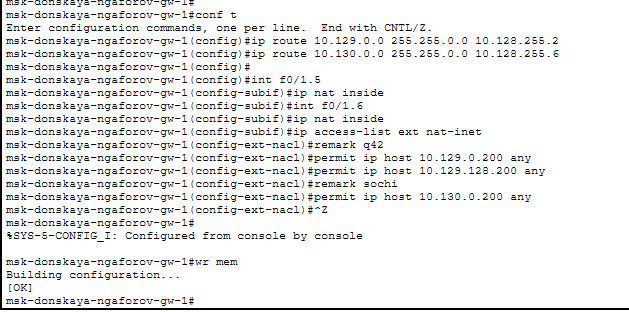

Статическая маршрутизация

## Маршруты по умолчанию

- Для сети общежития задан маршрут через 42-й квартал
- Для филиала в Сочи задан маршрут через сеть провайдера
- Это обеспечивает выход в остальные сети организации

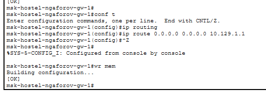

Маршрут по умолчанию общежития

## Настройка конечных устройств

- На ПК заданы статические IPv4-адреса
- Настроены:
  - маска подсети
  - шлюз по умолчанию
  - DNS-сервер

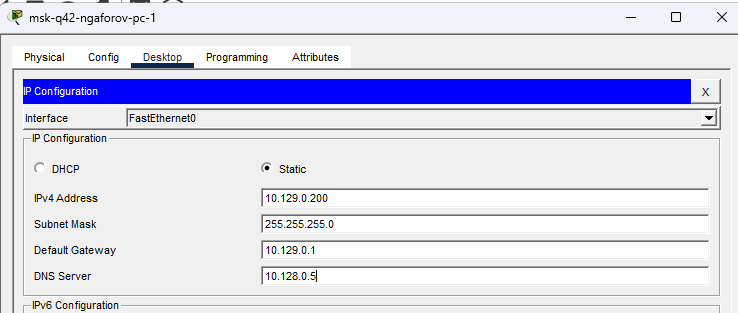

IP-адрес ПК 42-го квартала

## Проверка с ПК 42-го квартала

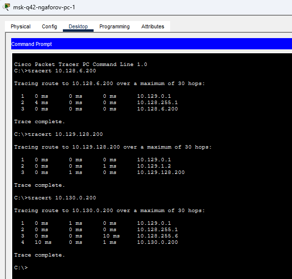

Трассировка с ПК 42-го квартала

## Проверка с ПК общежития

- Первым переходом является локальный шлюз
- Далее трафик проходит через сеть управления
- Маршрут до Сочи проходит через центральную сеть и провайдера

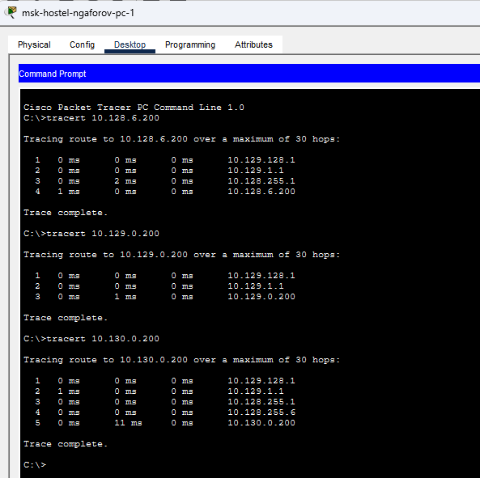

Трассировка с ПК общежития

## Проверка с ПК филиала

- Первым переходом является шлюз филиала
- Далее пакет передаётся через сеть провайдера
- Удалённые сети достигаются успешно

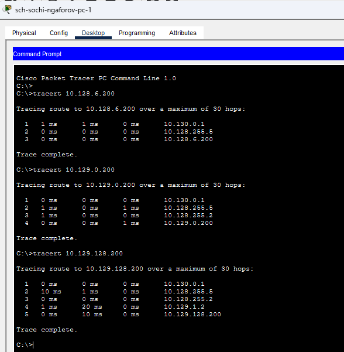

Трассировка с ПК филиала

## Таблица маршрутизации центрального маршрутизатора

- Отображаются напрямую подключённые сети
- Присутствуют статические маршруты
- Настроен маршрут по умолчанию во внешнюю сеть

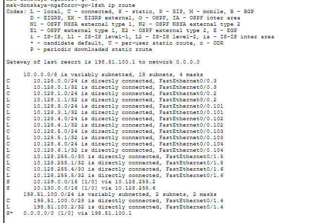

Таблица маршрутизации центрального маршрутизатора

## Таблицы маршрутизации филиалов

- На маршрутизаторах отображаются локальные VLAN
- Присутствуют маршруты по умолчанию
- Next-hop указывает направление передачи трафика

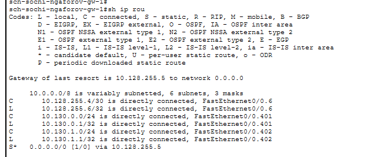

Таблица маршрутизации Сочи

# Итог

## Вывод

В ходе работы была настроена передача данных между локальными сетями организации через сеть провайдера.

Были использованы:

- VLAN
- trunk-соединения
- подинтерфейсы маршрутизаторов
- статическая маршрутизация
- маршруты по умолчанию

Работоспособность сети подтверждена трассировкой маршрутов и анализом таблиц маршрутизации.